# Time Series Analysis on e-Commerece Data to Predict the Price of a Product in FUTURE

# Problem Description

### Clear the Global Environment

```r
rm(list=ls(all=TRUE))
```

### Load required R library

```r
library(zoo)
library(dplyr)
library(TTR)
library(forecast)
library(DMwR)
library(data.table)
```

### Read Data from RData

- Set current working directory
- Use readRDS function to read RData file

```r
# setwd("I:/DATA-SCIENCE/FACULTY/BATCH-47/CSE7302c-Statistics and Probability in Decision Modeling/TimeSeries/20180922_Batch47_CSE7302c_Time_Series_LabActivity")
data = readRDS("ecommerceData.RData")
#data = readRDS("test.RData")
```

### Explore and understand the data

```r
## Dimension of the Data set
dim(data)
```

```
[1] 3316190       6
```

```r
## Look at the summary statistics
summary(data)
```

```
      V1               TitleKey           Price            Quantity       Condition
 Length:3316190     Min.   : 221205   Min.   :   0.01   Min.   :  1.00   Length:3316190
 Class :character   1st Qu.:1561944   1st Qu.:  63.97   1st Qu.:  1.00   Class :character
 Mode  :character   Median :4302628   Median :  86.85   Median :  1.00   Mode  :character
                    Mean   :4407778   Mean   :  91.82   Mean   : 30.77
                    3rd Qu.:6989428   3rd Qu.: 113.93   3rd Qu.:  3.00
                    Max.   :9186772   Max.   :2545.21   Max.   :999.00
     Date
 Length:3316190
 Class :character
 Mode  :character
```

[output not shown]

```r
## Look into Condition attribute
table(data$Condition)
```

```
Acceptable       Good       Mint        New  Very Good
    284251     778239     280389    1593241     380070
```

```r
## Look into Titlekey attribute
table(data$TitleKey)
```

```
 221205  273693  315169  367034  432113  433756  490823  506270  842501  879967 1018776 1091846 1118812
  32051   31991   32866   32574   32699   31663   32820   32597   32561   32724   33243   32307   32454
1123511 1138845 1140553 1198056 1205266 1288607 1462143 1464896 1515222 1523071 1532705 1541863 1561944
  32217   30684   32359   33702   32870   31814   31199   32598   32661   33088   32136   33188   31879
1619727 1644625 1707665 1752438 2096577 2231521 2422979 2437264 2443602 2446225 2450811 2451420 2660657
  32614   20176   32729   32794   31656   32727   32698   26246   32420   32333   33052   32394   34068
2773679 2808755 2871259 2873279 3019001 3119793 3120432 3121347 3128336 3128938 4283861 4289323 4302628
  29268   32905   32422   32431   32318   32415   32534   33361   32565   31071   33981   32555   33807
4389202 4456969 4505684 4511602 4676989 4687744 4688228 4690721 4702308 4705669 4730066 4735628 4770054
  32563   31470   32194   32530   31951   32336   32509   32344   32884   32940   32566   26243   32601
4793422 4862728 5124701 5294728 5724329 6252362 6254632 6399602 6485311 6760671 6871280 6896787 6915669
  32161   16454   32260   32343   29561   31273   32672   31525   29305   28499   30498   32065   31715
6989428 8044330 8045088 8046315 8046648 8046762 8048046 8049481 8050017 8366789 8374241 8768865 8772755
  29433   31558   31633   29719   29578   30837   30827   31212   30522   29475   33082   28739   32956
8778959 8787038 8799748 8830516 8896060 8944101 8946697 8973539 8977907 9000092 9010840 9062282 9078964
  28705   27884   30325   28957   26103   28412   25816   28363   27366   27926   28191   26821   27455
9117389 9149582 9186772
  26095   25606   26647
```

```r
## Find out number of the TitleKeys
length(unique(data$TitleKey))
```

```
[1] 107
```

```r
## Confirm whether V1 is unique for each of the record
length(unique(data$V1))
```

```
[1] 3316190
```

### Drop V1 unnecessary attribute and convert remaining attributes into appropriate type

```r
data$V1 = NULL
data$TitleKey = as.factor(data$TitleKey)
data$Price = as.numeric(data$Price)
data$Quantity = as.numeric(data$Quantity)
data$Condition = as.factor(data$Condition)
data$Date = as.Date(data$Date, format="%Y-%m-%d")
```

```r
# Summary of the data
summary(data)
```

```
    TitleKey           Price            Quantity           Condition            Date
 2660657:  34068   Min.   :   0.01   Min.   :  1.00   Acceptable: 284251   Min.   :2009-01-01
 4283861:  33981   1st Qu.:  63.97   1st Qu.:  1.00   Good      : 778239   1st Qu.:2010-06-14
 4302628:  33807   Median :  86.85   Median :  1.00   Mint      : 280389   Median :2011-08-31
 1198056:  33702   Mean   :  91.82   Mean   : 30.77   New       :1593241   Mean   :2011-08-17
 3121347:  33361   3rd Qu.: 113.93   3rd Qu.:  3.00   Very Good : 380070   3rd Qu.:2012-10-23
 1018776:  33243   Max.   :2545.21   Max.   :999.00                        Max.   :2013-12-02
 (Other):3114028
```

```r
# Re-look at the first 6 records
head(data)
```

| TitleKey | Price | Quantity | Condition | Date |
| --- | --- | --- | --- | --- |
| 8374241 | 73.40 | 1 | New | 2009-06-01 |
| 6252362 | 108.00 | 1 | Very Good | 2009-06-01 |
| 8049481 | 111.02 | 1 | Mint | 2009-06-01 |
| 6399602 | 127.80 | 1 | Mint | 2009-06-01 |
| 1091846 | 118.00 | 1 | New | 2009-06-01 |
| 1198056 | 44.90 | 1 | Mint | 2009-06-01 |

### Focusing on a particular product of choice

- Since different products price vary in a different way along the year we choose a particular product and the records that are in Good Condition.

```r
data = data[data$TitleKey==6989428 & data$Condition=="Good",]
```

### Basic info about that product

```r
dim(data)
```

```
[1] 5848    5
```

```r
summary(data)
```

```
    TitleKey        Price           Quantity           Condition         Date
 6989428:5848   Min.   : 39.84   Min.   : 1.000   Acceptable:   0   Min.   :2009-04-15
 221205 :   0   1st Qu.: 60.00   1st Qu.: 1.000   Good      :5848   1st Qu.:2011-01-26
 273693 :   0   Median : 72.25   Median : 1.000   Mint      :   0   Median :2012-03-01
 315169 :   0   Mean   : 73.30   Mean   : 3.334   New       :   0   Mean   :2011-12-31
 367034 :   0   3rd Qu.: 83.75   3rd Qu.: 3.000   Very Good :   0   3rd Qu.:2013-01-08
 432113 :   0   Max.   :999.00   Max.   :68.000                     Max.   :2013-12-02
 (Other):   0
```

```r
head(data)
```

| TitleKey | Price | Quantity | Condition | Date |
| --- | --- | --- | --- | --- |
| 6989428 | 84.38 | 1 | Good | 2009-12-08 |
| 6989428 | 115.98 | 1 | Good | 2009-06-01 |
| 6989428 | 115.98 | 1 | Good | 2009-06-02 |
| 6989428 | 84.38 | 1 | Good | 2009-12-09 |
| 6989428 | 115.98 | 1 | Good | 2009-06-03 |
| 6989428 | 84.38 | 1 | Good | 2009-12-10 |

```r
data = data[order(data$Date, decreasing=F), ]
head(data,10)
```

| TitleKey | Price | Quantity | Condition | Date |
| --- | --- | --- | --- | --- |
| 6989428 | 58.65 | 1 | Good | 2009-04-15 |
| 6989428 | 79.64 | 1 | Good | 2009-04-16 |
| 6989428 | 58.65 | 1 | Good | 2009-04-16 |
| 6989428 | 79.64 | 1 | Good | 2009-04-17 |
| 6989428 | 58.65 | 1 | Good | 2009-04-17 |
| 6989428 | 79.64 | 1 | Good | 2009-04-18 |
| 6989428 | 115.98 | 1 | Good | 2009-05-30 |
| 6989428 | 115.98 | 1 | Good | 2009-05-31 |
| 6989428 | 115.98 | 1 | Good | 2009-06-01 |
| 6989428 | 115.98 | 1 | Good | 2009-06-02 |

### Observation & Analysis

- On the given date, product has multiple prices, so one way is to consider the min price.
- Use dplyr package to do the same.

```r
data = data %>% group_by(Date) %>% summarise("MinPrice" = min(Price))
data = data.frame(data)
head(data,10)
```

|  | Date | MinPrice |
| --- | --- | --- |
| 1 | 2009-04-15 | 58.65 |
| 2 | 2009-04-16 | 58.65 |
| 3 | 2009-04-17 | 58.65 |
| 4 | 2009-04-18 | 79.64 |
| 5 | 2009-05-30 | 115.98 |
| 6 | 2009-05-31 | 115.98 |
| 7 | 2009-06-01 | 115.98 |
| 8 | 2009-06-02 | 115.98 |
| 9 | 2009-06-03 | 115.98 |
| 10 | 2009-06-04 | 115.98 |

### Handle missing values

- Some times there will be missing entries in dates, which will create a missing day/month/quarter/anual

### Detect missing values

- Using min and max date in the data, create new date field with continuous sequence of dates
- Check Data field in Data against newly created data field and find missing values.

```r
minDate = min(data$Date)
maxDate = max(data$Date)
seq = data.frame("DateRange"=seq(minDate, maxDate, by="days"))
data = seq %>% full_join(data, c("DateRange" = "Date"))
data = data.frame(data)
rm(minDate, maxDate, seq)
head(data)
```

|  | DateRange | MinPrice |
| --- | --- | --- |
| 1 | 2009-04-15 | 58.65 |
| 2 | 2009-04-16 | 58.65 |
| 3 | 2009-04-17 | 58.65 |
| 4 | 2009-04-18 | 79.64 |
| 5 | 2009-04-19 | NA |
| 6 | 2009-04-20 | NA |

### Impuation of Missing Values

- Replace the missing values by taking average of it’s preceding and succeeding values.
- For that, use na.locf function in the “zoo” package and rev function

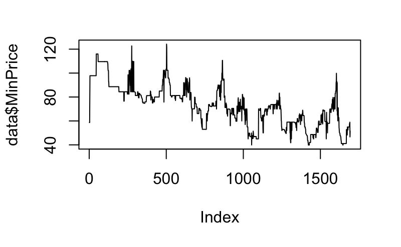

### Observation on MinPrice

- In this data set price is not changing much on daily basis, so it can be aggregated to Week level or Month level

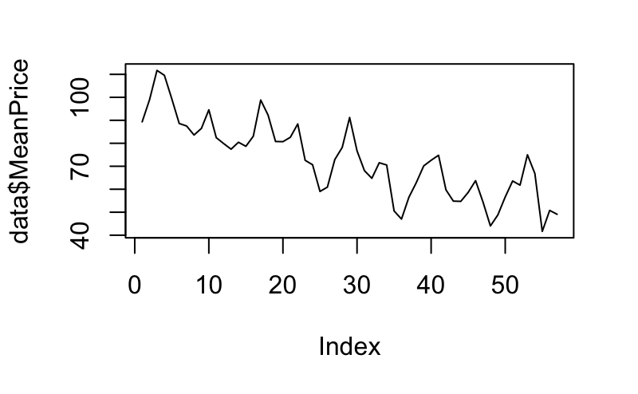

### Splitting of the Dataset into Train and Test

- As this data set is time dependent and sequence is important i.e. no random split.

```r
# View(data)
```

[output not shown]

### Converting data into R time series object

- Our target variable is price and price is aggrigated at month level

```r
test_TS
```

```
          Jan      Feb      Mar      Apr      May      Jun      Jul      Aug      Sep      Oct      Nov
2013 63.73032 54.42857 44.01097 48.79200 56.64129 63.58633 61.78355 74.99113 66.84800 41.66387 50.78450
          Dec
2013 49.10000
```

### Vizualize the time series Data

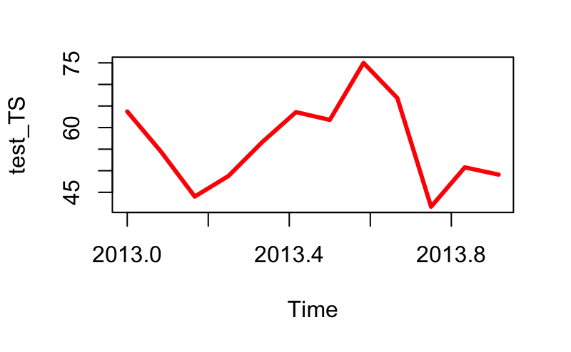

### Decomposed Time Series

- Decompose will provide more information on seasonality,trend and randomness

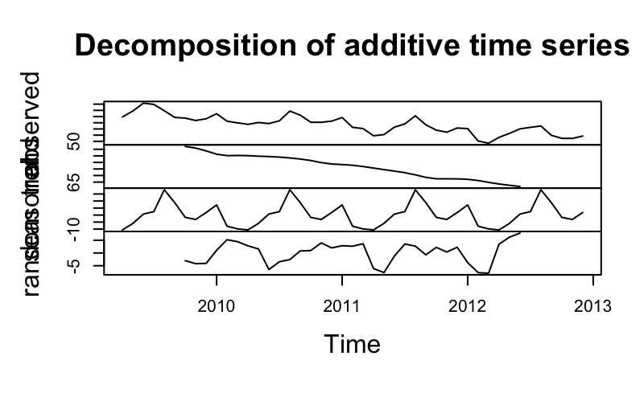

### ACF, PACF plots

- ACF: n th lag of ACF is the correlation between a day and n days before that. ??? PACF: The same as ACF with all intermediate correlations removed.

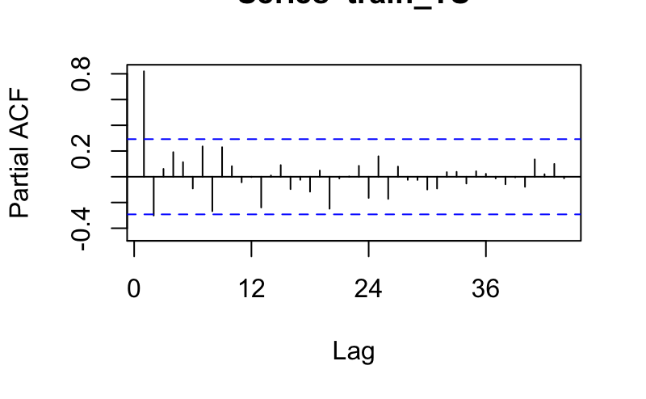

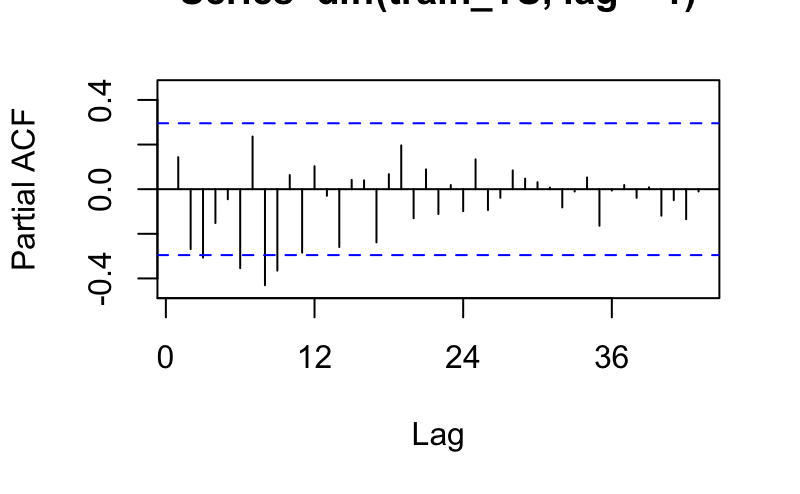

### Stationarize by differencing

- ndiffs and nsdiffs functions of forecast package can be used to findout the number of differences and seasonal differences, required to stationarize the data

```r
nsdiffs(train_TS)
```

```
[1] 1
```

### Modelling the time series using simple moving averages

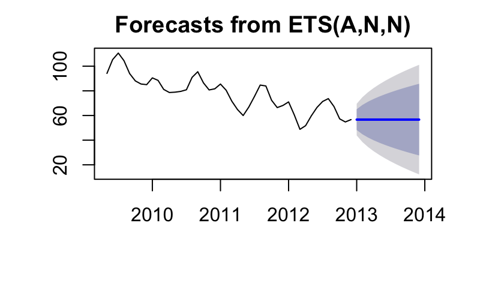

### Find error for SMA on both Test and Train data

```r
smaTestError
```

```
       mae        mse       rmse       mape
 8.2383969 92.2970065  9.6071331  0.1516664
```

### Weighted Moving Averages

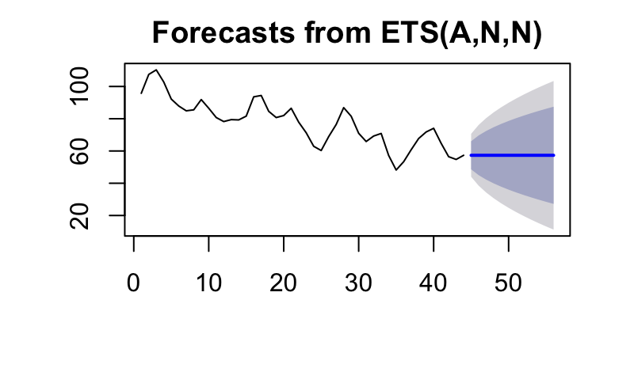

### Find error for WMA on both Test and Train data

```r
wmaTestError
```

```
       mae        mse       rmse       mape
 8.3471731 93.1249224  9.6501255  0.1553324
```

### Exponential Moving Averages

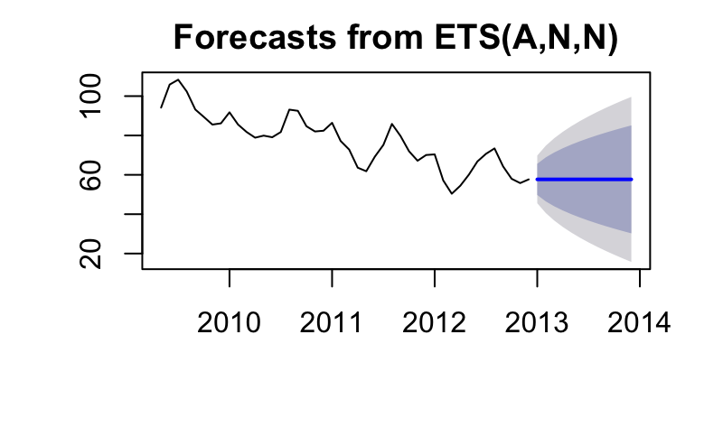

### Find error for EMA on both Test and Train data

```r
emaTestError
```

```
       mae        mse       rmse       mape
 8.4077278 93.9549518  9.6930363  0.1573733
```

## Regression on time

- As trend is also present Regression on time will also work.

### Simple Linear Regression

```r
points(train$Time, pred_Train, type="l", col="red", lwd=2)
```

[output not shown]

### Find error for lm1 on both Test and Train data

```r
lm1TestError
```

```
        mae         mse        rmse        mape
  9.1439128 131.9396415  11.4864982   0.1527641
```

### Linear Regression (Quadratic)

```r
points(train$Time, pred_Train, type="l", col="red", lwd=2)
```

[output not shown]

### Find error for lm2 on both Test and Train data

```r
lm2TestError
```

```
       mae        mse       rmse       mape
 7.9656467 97.2905284  9.8635961  0.1398358
```

### Seasonal Linear Regression Model using dummies

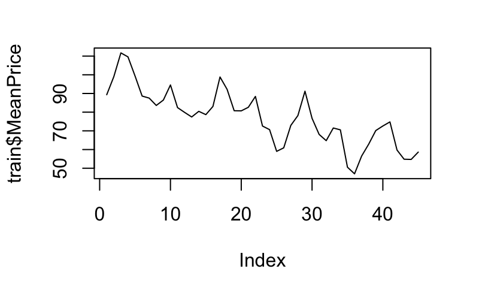

### Find error for slm1 on both Test and Train data

```r
slm1TestError
```

```
       mae        mse       rmse       mape
 6.8731154 66.1982183  8.1362288  0.1169832
```

## ARIMA Models

### Manual ARIMA Model

- The order of the model p is determined based on the number beyond which PACF terms are zero.
- The number of terms, q, is determined from the ACF plot. Its the m aximum lag beyond which the ACF is 0

### ACF and PACF Plots

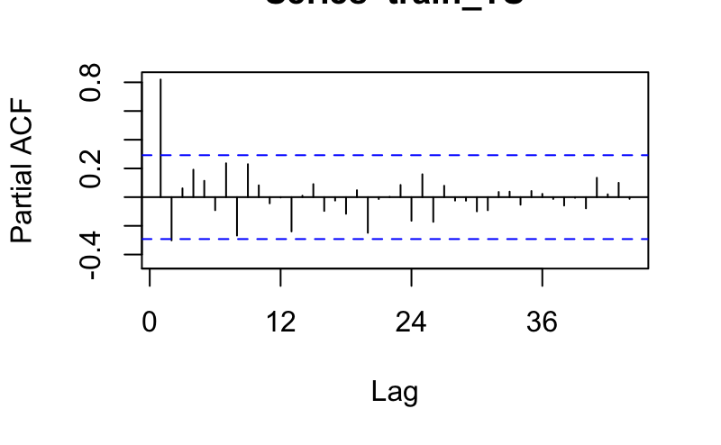

### Stationarize by differencing

- d is the number of non-seasonal differences
- D is the number of seasonal differences

```r
nsdiffs(train_TS)
```

```
[1] 1
```

- Lets do a seasonal differencing first and then plot Acf and Pacf

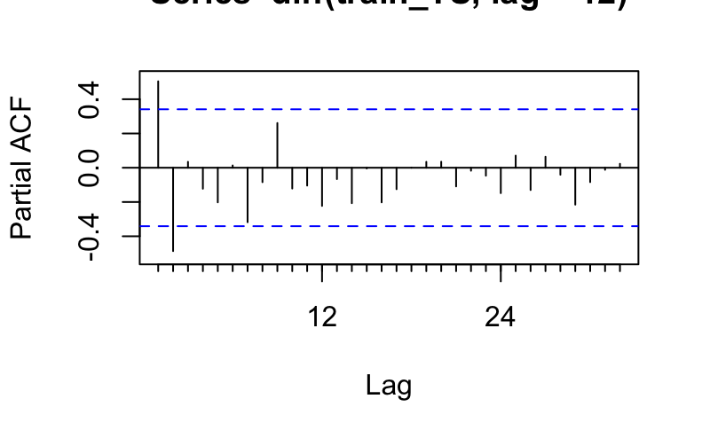

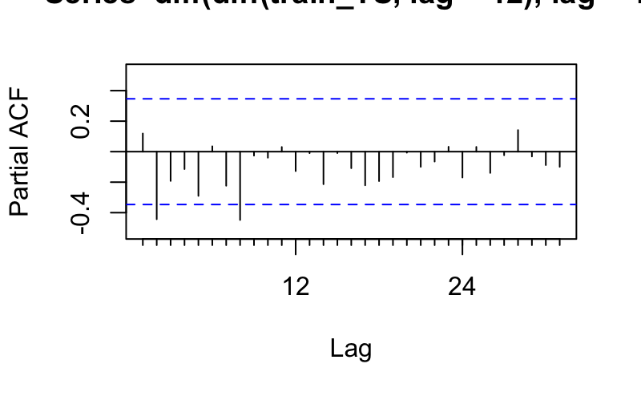

- ARIMA model ARIMA(2,1,2)(0,1,0)

```r
ARIMA_1 = Arima(train_TS, c(2,1,2), c(0,1,0))
summary(ARIMA_1)
```

[output not shown]

### Check the acf and pacf plots

```r
par(mfrow = c(1,2))
Acf(ARIMA_1$residuals)
Pacf(ARIMA_1$residuals)
```

[output not shown]

### Plots the residuals

```r
plot(ARIMA_1$residuals,ylim=c(-50,50))
points(ARIMA_1$residuals, type = 'l', col = "blue")
```

[output not shown]

### Box-Ljung Test

- Null Hypothesis : Error are not correlated
- Alternative Hypothesis: Error are correlated

```r
Box.test(ARIMA_1$residuals, type="Ljung-Box", lag = 24)

# No significant spikes
```

[output not shown]

## Predictions

### Prediction on the Train

```r
pred_Train = fitted(ARIMA_1)
pred_Train
pred_Test = forecast(ARIMA_1, h = 12)
```

### Find error for Arima_1 on both Test and Train data

```r
regr.eval(train$MeanPrice, pred_Train)

regr.eval(test$MeanPrice, data.frame(pred_Test)$Point.Forecast)
```

[output not shown]

### Auto Arima

```r
ARIMA_auto = auto.arima(train_TS)
summary(ARIMA_auto)
```

[output not shown]

### Forecast on autoARIMA model

```r
pred_Train = fitted(ARIMA_auto)
pred_Train
pred_Test = forecast(ARIMA_auto, h=12)
pred_Test
```

[output not shown]

### Find error for Arima_1 on both Test and Train data

```r
regr.eval(train$MeanPrice, pred_Train)

regr.eval(test$MeanPrice, data.frame(pred_Test)$Point.Forecast)
```

[output not shown]